# EDA_Lab_Assignment

Tristan Lampley

2023-12-11

# Explore the Ames Housing Dataset with R

The Ames Housing dataset has information on the home sales in Ames, Iowa between 2006 - 2010.

## 1. Load the Data

```r
df <- read.csv("/Users/Kurox/Desktop/DS311/EDA_Assignment/EDA_Assignment/EDA_Python_Tristan/data/ames.csv")
df <- df[, -1] # Remove index column
```

The following code checks the dimensions of the data.

```r
dim(df)
```

```
## [1] 1460   80
```

There are 1460 rows (homes) and 80 columns (variables) in the dataset.

Inspect the contents of the dataframe:

```r
df[1:40, 1:8] # First 40 observations and first 8 variables
```

|  | MSSubClass | MSZoning | LotFrontage | LotArea | Street | Alley | LotShape | LandContour |
| --- | --- | --- | --- | --- | --- | --- | --- | --- |
| 1 | 60 | RL | 65 | 8450 | Pave | NA | Reg | Lvl |
| 2 | 20 | RL | 80 | 9600 | Pave | NA | Reg | Lvl |
| 3 | 60 | RL | 68 | 11250 | Pave | NA | IR1 | Lvl |
| 4 | 70 | RL | 60 | 9550 | Pave | NA | IR1 | Lvl |
| 5 | 60 | RL | 84 | 14260 | Pave | NA | IR1 | Lvl |
| 6 | 50 | RL | 85 | 14115 | Pave | NA | IR1 | Lvl |
| 7 | 20 | RL | 75 | 10084 | Pave | NA | Reg | Lvl |
| 8 | 60 | RL | NA | 10382 | Pave | NA | IR1 | Lvl |
| 9 | 50 | RM | 51 | 6120 | Pave | NA | Reg | Lvl |
| 10 | 190 | RL | 50 | 7420 | Pave | NA | Reg | Lvl |

[output cut: 30 more lines]

```r
str(df)
```

```
## 'data.frame':    1460 obs. of  80 variables:
##  $ MSSubClass   : int  60 20 60 70 60 50 20 60 50 190 ...
##  $ MSZoning     : chr  "RL" "RL" "RL" "RL" ...
##  $ LotFrontage  : int  65 80 68 60 84 85 75 NA 51 50 ...
##  $ LotArea      : int  8450 9600 11250 9550 14260 14115 10084 10382 6120 7420 ...
##  $ Street       : chr  "Pave" "Pave" "Pave" "Pave" ...
##  $ Alley        : chr  NA NA NA NA ...
##  $ LotShape     : chr  "Reg" "Reg" "IR1" "IR1" ...
##  $ LandContour  : chr  "Lvl" "Lvl" "Lvl" "Lvl" ...
##  $ Utilities    : chr  "AllPub" "AllPub" "AllPub" "AllPub" ...
##  $ LotConfig    : chr  "Inside" "FR2" "Inside" "Corner" ...
##  $ LandSlope    : chr  "Gtl" "Gtl" "Gtl" "Gtl" ...
##  $ Neighborhood : chr  "CollgCr" "Veenker" "CollgCr" "Crawfor" ...
##  $ Condition1   : chr  "Norm" "Feedr" "Norm" "Norm" ...
##  $ Condition2   : chr  "Norm" "Norm" "Norm" "Norm" ...
```

[output cut: 66 more lines]

## 2. Explore Data Distributions

### Sale Price

Histogram for SalePrice:

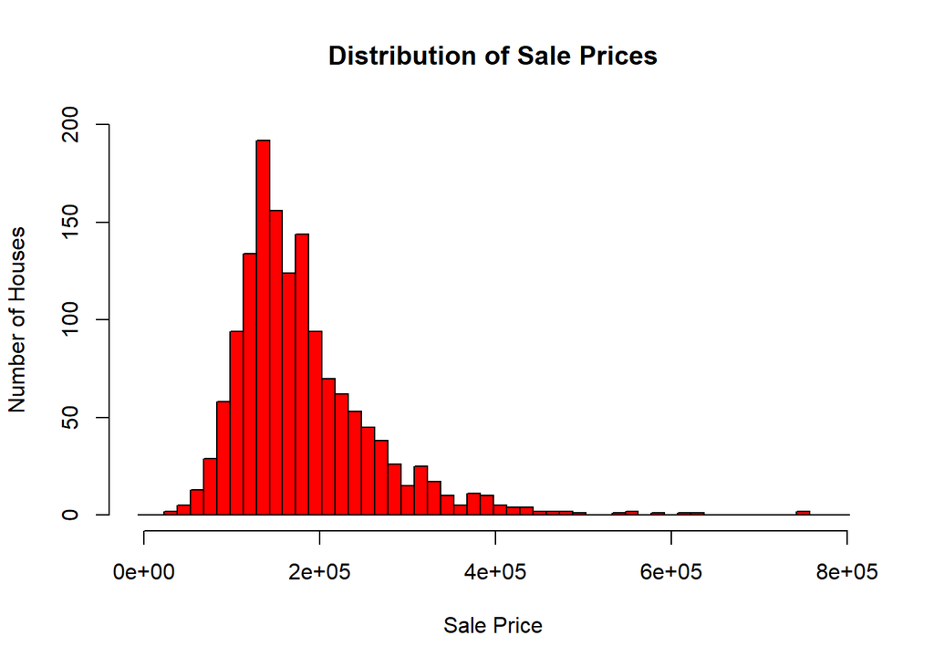

```r
hist(df$SalePrice, xlab = "Sale Price", col = ("#FF0000"),
     ylab = "Number of Houses", main = "Distribution of Sale Prices",
     breaks = seq(-7500, 802500, by = 15000), ylim = c(0, 200))
```

Summary statistics:

```r
y = df$SalePrice

text <- function(y) {
  noquote(c(paste("Median:", median(y)), paste("Mean:", mean(y)),
                 paste("Standard Deviation:", sd(y))))
}

summary(y); cat(text(y), sep="\n")
```

```
##    Min. 1st Qu.  Median    Mean 3rd Qu.    Max.
##   34900  129975  163000  180921  214000  755000
```

```
## Median: 163000
## Mean: 180921.195890411
## Standard Deviation: 79442.5028828866
```

Sales price median is 163000 while the mean is 180 almost 181000 the higher homes are what is bringing the mean so high

##Histogram for Total rooms above grade:

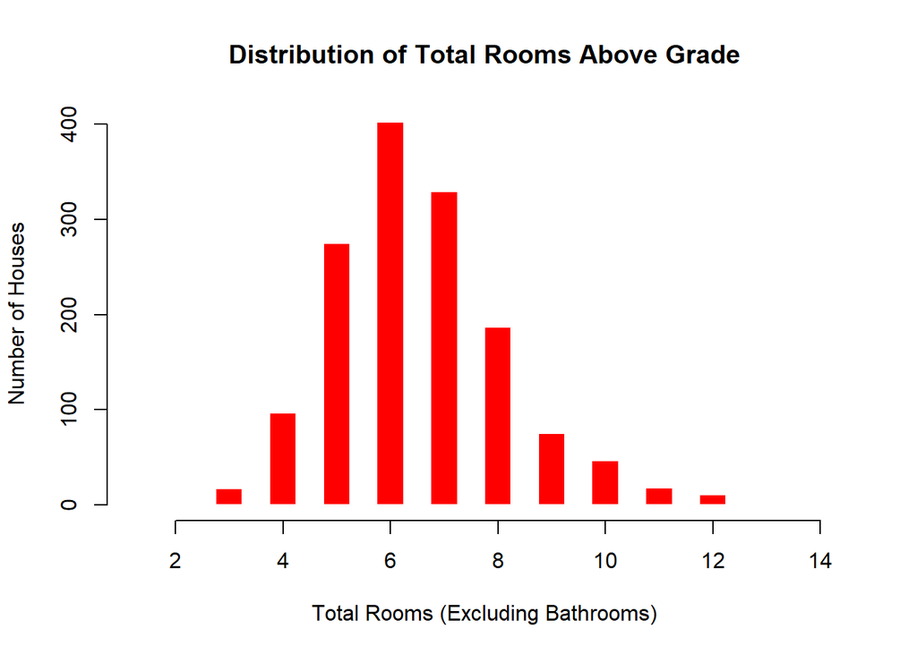

```r
hist(df$TotRmsAbvGrd, xlab = "Total Rooms (Excluding Bathrooms)",
     ylab = "Number of Houses", breaks = seq(1.25, 14.25, by = 0.5),
     main = "Distribution of Total Rooms Above Grade",
     col = ("#FF0000"), border=par('bg'))
```

Summary statistics:

```r
y = df$TotRmsAbvGrd
summary(y); cat(text(y), sep="\n")
```

```
##    Min. 1st Qu.  Median    Mean 3rd Qu.    Max.
##   2.000   5.000   6.000   6.518   7.000  14.000
```

```
## Median: 6
## Mean: 6.51780821917808
## Standard Deviation: 1.62539329058405
```

The median of these groups of houses are at 6 and other houses go over that and can even double that

##Histogram for Overall Condition:

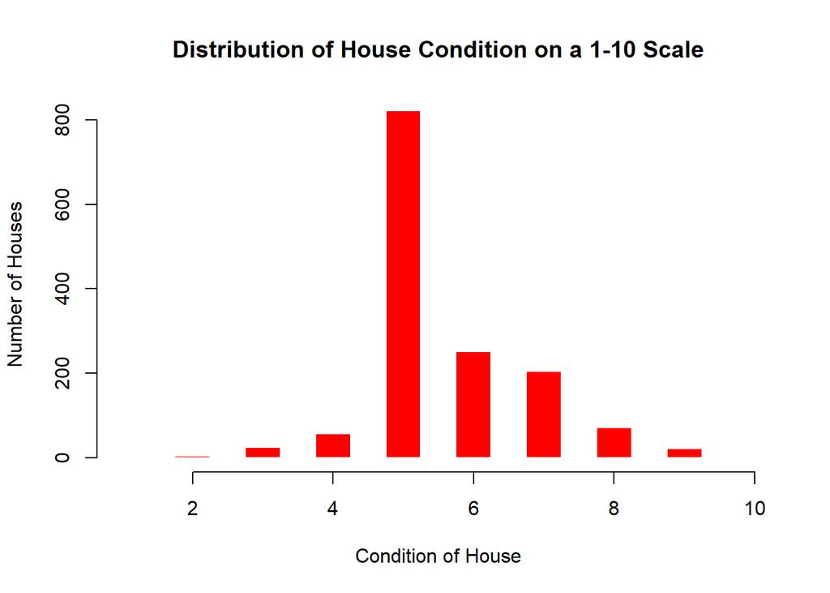

```r
hist(df$OverallCond, xlab = "Condition of House",
     ylab = "Number of Houses", breaks = seq(0.75, 9.25, by = 0.5),
     main = "Distribution of House Condition on a 1-10 Scale",
     xlim = range(1,10),
     col = ("#FF0000"), border=par('bg'))
```

Summary statistics:

```r
y = df$OverallCond
summary(y); cat(text(y), sep="\n")
```

```
##    Min. 1st Qu.  Median    Mean 3rd Qu.    Max.
##   1.000   5.000   5.000   5.575   6.000   9.000
```

```
## Median: 5
## Mean: 5.57534246575342
## Standard Deviation: 1.11279933671273
```

Most homes have a condition are at a 5 looking at this from houses being in the 5 category meaning that houses are in the middle in terms of quality and condition

## 3. Explore Differences between Subsets

One useful way to explore a categorical variable is to create subsets of the full data set based on that categorical variable, then plot their distributions based on some other variable. Since this data set is traditionally used for predicting the sale price of a house, let’s use Sale Price as that other variable.

Create three variables, each of which represents a record-wise subset of df (meaning, it has the same columns as df, but only some of the rows).

- below_average_condition: home sales where the overall condition was less than 5
- average_condition: home sales where the overall condition was exactly 5
- above_average_condition: home sales where the overall condition was greater than 5

```r
below_average_condition = df[df$OverallCond < 5, ]
average_condition = df[df$OverallCond == 5, ]
above_average_condition = df[df$OverallCond > 5, ]
```

The following code will produce a plot of the distributions of sale price for each of these subsets:

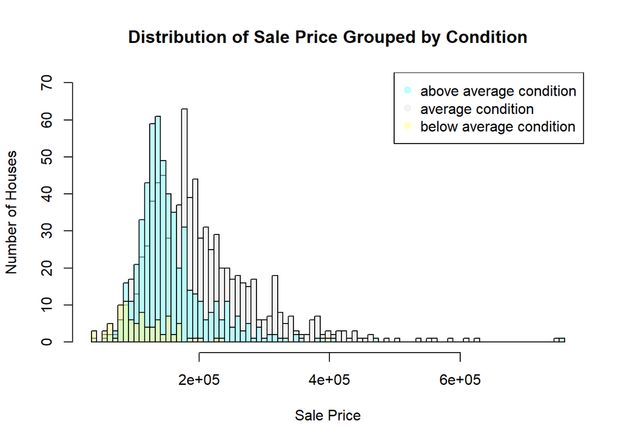

```r
a = below_average_condition$SalePrice
b = average_condition$SalePrice
c = above_average_condition$SalePrice

# Create colors with reduced opacity (alpha) to see overlap
c1 = rgb(255,255,127, max = 255, alpha = 120) # Yellow
c2 = rgb(216,216,216, max = 255, alpha = 70)  # Grey
c3 = rgb(127,255,255, max = 255, alpha = 128) # Cyan

# Create custom bins so all are on the same scale
breaks_by = as.integer(median(df$SalePrice) / 20)
breaks_seq = seq(min(df$SalePrice), max(df$SalePrice) + breaks_by,
                 by = breaks_by)

hgA = hist(a, breaks = breaks_seq, plot = FALSE)
hgB = hist(b, breaks = breaks_seq, plot = FALSE)
hgC = hist(c, breaks = breaks_seq, plot = FALSE)

# Plot three histograms
plot(hgB, col = c2, ylim = c(0, 70),
     xlab = "Sale Price", ylab = "Number of Houses",
     main = "Distribution of Sale Price Grouped by Condition")
plot(hgC, col = c3, add = TRUE)
plot(hgA, col = c1, add = TRUE)
legend("topright",
       legend = c("above average condition",
                  "average condition",
                  "below average condition"),
       col = c(c3, c2, c1), cex = 1,
       pch = 20, pt.cex = 1.5)
```

Summary statistics: Looking at the graph shown above most houses are in average condition, some have above average, and there are minimal with less than average condition, averages are filling up the sale price across the graph.

## 4. Explore Correlations

To understand more about what features of these homes lead to higher sale prices, let’s look at some correlations. We’ll return to using the full df, rather than the subsets.

In the cell below, print out both the name of the column and the Pearson correlation for the column that is most positively correlated with Sale Price (other than Sale Price, which is perfectly correlated with itself).

We’ll only check the correlations with some kind of numeric data type.

```r
# Create a df that contains only numeric columns
# and doesn't include Sale Price
numeric_df = df[, unlist(lapply(df, is.numeric))]
numeric_df = numeric_df[, !names(numeric_df) %in% "SalePrice"]

# Create list of correlations
correlations = cor(numeric_df, df$SalePrice)

# Find the largest value, and the column name at that index
max_corr_value = max(correlations, na.rm = TRUE)
i = which(correlations == max_corr_value)
max_corr_column = rownames(correlations)[[i]]

noquote(c(paste("Most Positively Correlated Column:",
                max_corr_column),
          paste("Most Positively Correlated Value:",
                max_corr_value)))
```

```
## [1] Most Positively Correlated Column: OverallQual
## [2] Most Positively Correlated Value: 0.790981600583805
```

Now, find the most negatively correlated column:

```r
min_corr_value = min(correlations, na.rm = TRUE)
j = which(correlations == min_corr_value)
min_corr_column = rownames(correlations)[[j]]

noquote(c(paste("Most Negatively Correlated Column:",
                min_corr_column),
          paste("Most Negative Correlated Value:",
                min_corr_value)))
```

```
## [1] Most Negatively Correlated Column: KitchenAbvGr
## [2] Most Negative Correlated Value: -0.135907370842141
```

Boxplots of the relevant columns:

```r
library(RColorBrewer)
colors = brewer.pal(n = length(unique(df[, max_corr_column])),
                    name = "Set2")
```

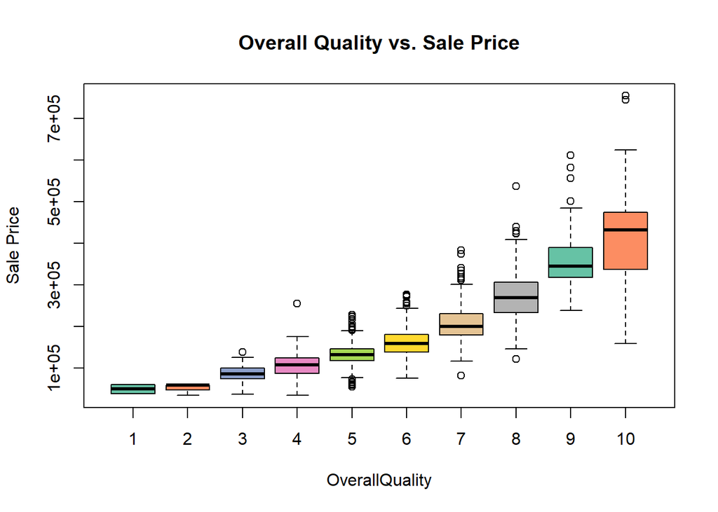

```r
colors2 = brewer.pal(n = length(unique(df[, min_corr_column])),
                    name = "Set3")

boxplot(df$SalePrice ~ df[, max_corr_column],
        xlab = "OverallQuality", ylab = "Sale Price",
        main = "Overall Quality vs. Sale Price",
        col = colors)
```

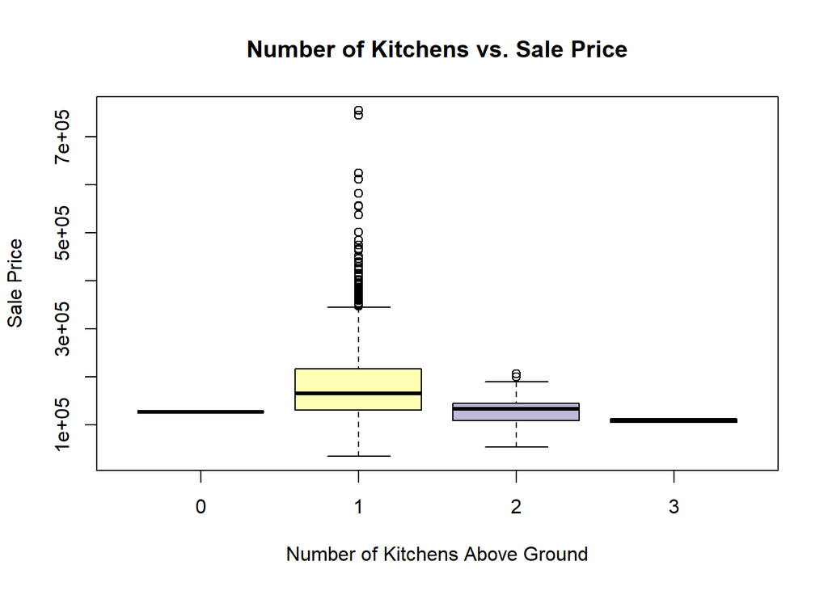

```r
boxplot(df$SalePrice ~ df[, min_corr_column],
        xlab = "Number of Kitchens Above Ground",
        ylab = "Sale Price", col = colors2,
        main = "Number of Kitchens vs. Sale Price")
```

The column with the highest correlation is overall quality. According to the data description:

Overall Quality: Rates the overall material and finish of the house

1 Very Poor, 2 poor, 3 fair, 4 below average, 5 average, 6 above average, 7 good, 8 very good, 9 excellent, 10 very excellent

[output not shown]